# TD3 : Filtrage et Morphologie Mathématique

Pour cette séance, on découvre des algorithmes de prétraitement et post traitement. Aujourd'hui, nous allons donc développer plusieurs algorithmes classiques de filtrage et de morphologie mathématique.

Tout d'abord, importez les librairies qui seront nécessaires pour ce TD : Numpy, OpenCV (cv2), Matplotlib, et autres si vous le souhaitez.

```python
# Import des libraries
from matplotlib import pyplot as plt
import numpy as np
import cv2
import itertools
from scipy.ndimage.interpolation import shift
import pandas as pd
```

Puis, chargez l'image bruitée en niveaux de gris que vous souhaitez pour ce TP, et affichez la.

/!\ : Il nous faut une image en noir et blanc, donc avec uniquement un seul channel (matrice 2D). Pour cela, utilisez cv2.imread, avec en premier argument le chemin d'accès de votre image, et en second argument 0 (pour signifier que vous la souhaitez en niveaux de gris)

[figure not shown]

[figure not shown]

```python
# A compléter
# Chargement de l'image bruitée de votre choix
image_s_p = cv2.imread('images/astronaut_s&p.jpg',0)
image_gauss = cv2.imread('images/cameraman_gauss.jpg',0)

# Affichage de l'image bruitée
plt.figure()
plt.imshow(image_s_p,'gray')
plt.figure()
plt.imshow(image_gauss,'gray')
```

# Partie 1: Filtres de prétraitement

## Ex. 1 : Filtre moyenneur

Nous allons donc développer plusieurs algorithmes de filtrage vus en cours, afin de les corriger :D

Commençons d'abord par le filtre moyenneur

**1.**

Implémentez une fonction de filtrage moyenneur de taille *nxn* avec *n* impair. Pour cela, sur chaque pixel de votre image d'entrée vous allez sélectionner une fenêtre de taille *nxn* centrée et calculer la moyenne de cette fenêtre pour obtenir la valeur du pixel pour l'image corrigée.

```python
# A compléter
# Développement de la fonction de filtrage moyenneur
def mean_filter(img,n):
    h,w = img.shape
    new_img = np.empty((h,w),dtype=np.uint8)
    for i in range(h):
        for j in range(w):
            fenetre = img[max(i-n//2,0):min(1+i+n//2,h),max(0,j-n//2):min(1+j+n//2,w)]
            new_img[i,j] = np.mean(fenetre)
    return new_img

def mean_filter_fast(img,n):
    return np.floor(sum([shift(img.astype(np.float32),(i-n//2,j-n//2),cval=np.NaN) for i,j in itertools.product(range(n),range(n))])/(n*n)).astype(np.uint8)
```

Affichez le résultat de l'application du filtre moyenneur sur l'image bruitée.

[figure not shown]

[figure not shown]

```python
# A compléter
# Filtrage moyenneur sur l'image bruitée
n=3
mean_image_s_p = mean_filter(image_s_p,n)
mean_image_s_p_2 = mean_filter_fast(image_s_p,n)

# Affichage de l'image corrigée
plt.figure()
plt.imshow(mean_image_s_p,'gray')
plt.figure()
plt.imshow(mean_image_s_p_2,'gray')
```

Que contastez vous sur l'image corrigée ?

*Réponse :*

Que se passe-t-il si on augmente la taille du filtre moyenneur ?

*Réponse :*

**2.**

Testez votre algorithme sur d'autres images bruitées (avec un bruit différent), et des tailles de fenêtre différentes.

[figure not shown]

[figure not shown]

```python
# A compléter
# Filtrage moyenneur sur l'image bruitée
n=7
mean_image_gauss = mean_filter(image_gauss,n)
mean_image_gauss_2 = mean_filter_fast(image_gauss,n)

# Affichage de l'image corrigée
plt.figure()
plt.imshow(mean_image_gauss,'gray')
plt.figure()
plt.imshow(mean_image_gauss_2,'gray')
```

Le filtre est-il plus efficace sur certains types de bruit ?

*Réponse :*

## Ex. 2 : Filtre médian

Implémentez maintenant une fonction de filtrage médian de taille *nxn* avec *n* impair.

*Note :* Si votre filtre moyenneur est bien implémenté, normalement, il y a juste une seule fonction à changer...

```python
# A compléter
# Développement de la fonction de filtrage médian
def median_filter(img,n):
    h,w = img.shape
    new_img = np.empty((h,w),dtype=np.uint8)
    for i in range(h):
        for j in range(w):
            fenetre = img[max(i-n//2,0):min(1+i+n//2,h),max(0,j-n//2):min(1+j+n//2,w)]
            new_img[i,j] = np.median(fenetre)
    return new_img

def median_filter_faster(img,n):
    return np.floor(np.nanmedian(np.stack([shift(img,(i-n//2,j-n//2),cval=np.NaN) for i,j in itertools.product(range(n),range(n))],axis=-1),axis=(-1))).astype(np.uint8)
```

Vous connaissez déjà la chanson : Affichez le résultat de l'application du filtre médian sur différentes images bruitées, avec plusieurs tailles de fenêtre.

[figure not shown]

[figure not shown]

```python
# A compléter
# Filtrage médian sur l'image bruitée
n=3
median_image_s_p = median_filter(image_s_p,n)
median_image_s_p_2 = median_filter_faster(image_s_p,n)

# Affichage de l'image corrigée
plt.figure()
plt.imshow(median_image_s_p,'gray')
plt.figure()
plt.imshow(median_image_s_p_2,'gray')
```

Comparé au filtre moyenneur, quels sont les avantages et inconvénients du filtre médian ?

*Réponse :*

Dans quel cas l'utilisation du filtre médian est plus efficace que le filtre moyenneur ?

*Réponse :*

## Ex. 3 : Filtre par convolution

La méthode de filtrage la plus utilisée car plus globale est le filtrage par convolution. A partir d'une seule fonction, on peut effectuer plein de types de filtrage différents. Pour cela, il faut définir un masque de convolution *h* (une matrice). Pour une image *A*, avec le masque *h*, le résultat sortant est : \begin{equation*} C[i,j] = \sum_{k \in W} \sum_{l \in W} h[k,l]A[i-k,j-l] \end{equation*} Un pixel *A[i,j]* est remplacé par une somme pondérée de lui-même et des pixels de son voisinage *W*.

**1.**

Développez la fonction de convolution avec en paramètres votre image ainsi qu'un masque h.

```python
# A compléter
# Implémentation de la fonction de convolution
def convolution(img,h):
    h_rows,h_cols=h.shape
    rows,cols = img.shape
    large_img = np.zeros((rows+h_rows-1,cols+h_cols-1),dtype=np.uint8)
    large_img[h_rows//2:h_rows//2+rows,h_cols//2:h_cols//2+cols]=img
    out_img = np.zeros((rows,cols),dtype=np.uint8)
    for i in range(rows):
        for j in range(cols):
            out_img[i,j]=np.sum(large_img[i:i+h_rows,j:j+h_cols]*h)
    return out_img

def convolution_faster(img,h):
    h_rows,h_cols=h.shape
    h = h.reshape((-1,))
    rows,cols = img.shape
    large_img = np.stack([shift(img.astype(np.float32),(i-h_rows//2,j-h_cols//2),cval=np.NaN) for i,j in itertools.product(range(h_rows),range(h_cols))],axis=-1)
    return np.dot(large_img,h).astype(np.uint8)
```

**2.**

On va tester la fonction précédemment codée, mais il vous faut pour cela un masque. On va commencer par effectuer un filtre moyenneur par convolution (oui, comme le premier filtre codé).

Quel masque de convolution de taille 3x3 correspondrait à un filtre moyenneur ?

*Réponse :*

Créez ce masque de convolution pour un filtrage moyenneur

```python
# A compléter
# Création du masque de convolution pour un filtrage gaussien
n=3
mean_h = np.ones((n,n))/(n*n)
```

Appliquez votre filtre de convolution avec votre masque créé sur une de vos images bruitées, et comparez le résultat avec le filtre moyenneur développé précédemment dans l'exercice 1.

[figure not shown]

[figure not shown]

```python
# A compléter
# Filtrage moyenneur par convolution sur l'image bruitée
n=3
conv_mean_image_gauss = convolution(image_gauss,mean_h)
conv_mean_image_gauss_2 = convolution_faster(image_gauss,mean_h)

# Affichage de l'image corrigée
plt.figure()
plt.imshow(conv_mean_image_gauss,'gray')
plt.figure()
plt.imshow(conv_mean_image_gauss_2,'gray')
```

Obtenez-vous exactement les mêmes résultats qu'avec le filtre moyen de l'exercice 1 ?

*Réponse :*

Quel est l'avantage du filtrage par convolution moyenneur par rapport au filtre moyenneur de l'exercice 1 ?

*Réponse :*

Peut-on faire un filtre médian par convolution ? Si oui, quel serait le masque de convolution à utiliser ?

*Réponse :*

**3.**

Passons au filtre gaussien ! Plus aucune fonction à coder, on a juste à définir le masque de convolution, qui prendra la forme suivante :

\begin{equation*} h(x,y) = \frac{1}{2 \pi \sigma^{2}} exp(-\frac{(x^{2}+y^{2})}{2 \sigma^{2}}) \end{equation*}

La formule est jolie, mais pour faire plus simple, nous allons définir les masques à la main, qui sont un arrondi de la formule. Par exemple, le masque suivant que vous allez créer est une approximation avec $\sigma = 0.8$ pour un masque de taille $3x3$. \begin{equation*} h = \frac{1}{16} \begin{vmatrix} 1 & 2 & 1 \\ 2 & 4 & 2 \\ 1 & 2 & 1 \end{vmatrix} \end{equation*}

Créez le masque gaussien décrit ci-dessus

```python
# A compléter
# Création du masque de convolution pour un filtrage gaussien
gauss_h = np.array([[1,2,1],[2,4,2],[1,2,1]],dtype=np.float64)/16
```

Affichez le résultat de l'application de la convolution avec le kernel gaussien sur l'image bruitée.

[figure not shown]

[figure not shown]

```python
# A compléter
# Filtrage gaussien par convolution sur l'image bruitée
gauss_image_s_p = convolution(image_s_p,gauss_h)
gauss_image_s_p_2 = convolution_faster(image_s_p,gauss_h)

# Affichage de l'image corrigée
plt.figure()
plt.imshow(gauss_image_s_p,'gray')
plt.figure()
plt.imshow(gauss_image_s_p_2,'gray')
```

Une petite analyse des résultats ? Que constatez-vous sur les images corrigées par rapport aux autres filtres ?

*Réponse :*

**4.**

On finit avec un dernier filtre, toujours par convolution : le filtre exponentiel. Même principe que tout à l'heure : une convolution avec un masque de ce type : \begin{equation*} h(x,y) = \frac{\gamma^{2}}{4}exp(-\gamma(|x|+|y|)) \end{equation*}

Pour ce dernier filtre, créez le masque suivant : \begin{equation*} h = \frac{1}{80} \begin{vmatrix} 1 & 1 & 3 & 1 & 1 \\ 1 & 3 & 7 & 3 & 1 \\ 3 & 7 & 16 & 7 & 3 \\ 1 & 3 & 7 & 3 & 1 \\ 1 & 1 & 3 & 1 & 1 \\ \end{vmatrix} \end{equation*}

```python
# A compléter
# Création du masque de convolution pour le filtrage exponentiel
expo_h = np.array([[1,1,3,1,1],
                  [1,3,7,3,1],
                  [3,7,16,7,3],
                  [1,3,7,3,1],
                  [1,1,3,1,1]],dtype=np.float64)/80
```

Affichez le résultat de l'application de la convolution avec le kernel exponentiel sur l'image bruitée.

[figure not shown]

[figure not shown]

```python
# A compléter
# Filtrage exponentiel par convolution sur l'image bruitée
expo_image_s_p = convolution(image_s_p,expo_h)
expo_image_s_p_2 = convolution_faster(image_s_p,expo_h)

# Affichage de l'image corrigée
plt.figure()
plt.imshow(expo_image_s_p,'gray')
plt.figure()
plt.imshow(expo_image_s_p_2,'gray')
```

# Partie 2 : Morphologie Mathématique

Maintenant, place à la morphologie mathématique. C'est avant tout un ensemble de methodes pour le traitement de la forme des objets dans une image. L'objectif principal de cette famille d'algorithme est de supprimer le bruit introduit par des opérations de segmentation. On utilise donc souvent un algorithme MM en traitement ou en post-traitement.

Pour cette partie, chargez l'image noisy_yin_yang.png en niveaux de gris.

[figure not shown]

```python
# A compléter
# Chargement de l'image et affichage
yinyang = cv2.imread('images/noisy_yin_yang.png',0)
plt.imshow(yinyang,'gray')
```

Votre image est assez grande (1200x1200). Pour avoir des temps de calcul corrects, je vous conseille de la redimensionner avec le petit code ci-dessous :

```python
# Complétez les ... avec votre image (je ne connais pas d'avance le nom de votre variable)

yinyang = cv2.resize(yinyang,(400,400))
```

Dans le cadre de la morphologie mathématique, il nous faut obligatoirement ce qu'on appelle un élément structurant ou kernel. C'est un tableau/masque binaire qui sera appliqué sur notre image à traiter en fonction de l'algorithme utilisé. Plusieurs tailles et formes de kernel existent ici. Au lieu de les fabriquer nous même, on va utiliser une superbe fonction d'OpenCV : getStructuringElement.

Avec cette fonction, construisez et affichez :

- Un kernel rectangulaire 5X5
- Un kernel elliptique 7X7
- Un kernel en croix 3x3
- Un kernel rectangulaire 3X11

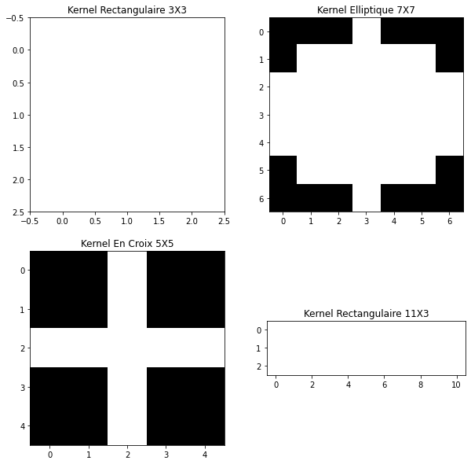

```python
# A compléter
# Construction et affichage des kernels

plt.figure()

# Création d'un kernel rectangulaire 5X5
kernel_rect_3_3 = cv2.getStructuringElement(cv2.MORPH_RECT,(3,3))

# Création d'un kernel elliptique 7X7
kernel_ellipse_7_7 = cv2.getStructuringElement(cv2.MORPH_ELLIPSE,(7,7))

# Création d'un kernel en croix 3X3
kernel_cross_5_5 = cv2.getStructuringElement(cv2.MORPH_CROSS,(5,5))

# Création d'un kernel rectangulaire 11X3
kernel_rect_11_3 = cv2.getStructuringElement(cv2.MORPH_RECT,(11,3))

plt.subplots(2,2,figsize=(10,10))
plt.subplot(221)
plt.imshow(kernel_rect_3_3,'gray',vmin=0,vmax=1)
plt.title('Kernel Rectangulaire 3X3')
plt.subplot(222)
plt.imshow(kernel_ellipse_7_7,'gray',vmin=0,vmax=1)
plt.title('Kernel Elliptique 7X7')
plt.subplot(223)
plt.imshow(kernel_cross_5_5,'gray',vmin=0,vmax=1)
plt.title('Kernel En Croix 5X5')
plt.subplot(224)
plt.imshow(kernel_rect_11_3,'gray',vmin=0,vmax=1)
plt.title('Kernel Rectangulaire 11X3')
plt.show()
```

## Ex. 1 : Développement des algorithmes de Morphologie Mathématique

**1.**

Commençons d'abord avec l'érosion. Dans le cadre des images binaires (notre cas ;) ), l'érosion d'une image I par un kernel K consiste en l'opération suivante :

$ {\epsilon}_K(I) = \{ x|K_{x} \subset I \}$

C'est-à-dire, l'ensemble des points x tels que K soit totalement inclus dans I avec K centré en x.

Dans ce principe, développez la fonction d'érosion d'une image I par un kernel K.

*Note :* Comme pour le filtre par convolution, les algos de morphologie mathématiques utilisent le principe de fenêtre glissante. Je vous conseille donc de ne pas coder à zéro, mais de recopier votre fonction de convolution et de la modifier.

```python
# A compléter
# Développement de la fonction d'érosion
def erosion(I,K):
    height,width = I.shape
    k_height,k_width = K.shape
    output = np.zeros((height,width),dtype=np.uint8)
    I_extended = np.zeros((height+k_height-1,width+k_width-1),dtype=np.uint8)
    I_extended[k_height//2:k_height//2+height,k_width//2:width+k_width//2]=I
    for i in range(height):
        for j in range(width):
            imagette = I_extended[i:k_height+i,j:k_width+j].astype(np.bool)
            output[i,j] = np.all(imagette[K.astype(np.bool)])
    return output

def erosion_faster(I,K):
    # On concatène plusieurs fois la même image mais avec un décalage.
    # Si on a un filtre 5X5, on aura donc 25 images concatenées, avec un décalage en x allant de -2 à 2 et un décalage en y allant de -2 à 2.
    # Donc sur l'axe de concaténation, on obtient pour chaque position (x,y) un vecteur de taille 25 avec les valeurs correspondants à la fenêtre englobante.
    b=np.stack([shift(I.astype(np.uint8),(i-K.shape[0]//2,j-K.shape[1]//2),cval=np.NaN).astype(np.bool) for i,j in itertools.product(range(K.shape[0]),range(K.shape[1]))])
    # De ce vecteur, on va sélectionner uniquement les valeurs vraies (1) de l'élement structurant.
    a=b[K.astype(np.bool).reshape(-1),:,:]
    # Pour finir, sur cet axe de concaténation, on va vérifier que toutes les valeurs sont vraies (1) pour définir le pixel à vrai (1). Si ce n'est pas le cas, le pixel sera faux (0).
    return np.all(a,axis=0)
```

Appliquez l'érosion sur votre image bruitée avec le kernel en croix 5X5 et affichez le résultat.

[figure not shown]

[figure not shown]

```python
# A compléter
# Application de la fonction d'érosion sur l'image yinyang bruitée
erode_yinyang = erosion(yinyang,kernel_cross_5_5)
erode_faster_yinyang = erosion_faster(yinyang,kernel_cross_5_5)

# Affichage du résultat
plt.figure()
plt.imshow(erode_yinyang,'gray')
plt.figure()
plt.imshow(erode_faster_yinyang,'gray')
```

Que constatez-vous sur l'image corrigée ? Quel bruit a été corrigé ? Quel bruit n'a pas été corrigé ?

*Réponse :* Le bruit blanc a été très diminué (il reste quelques artefacts plus gros, donc utiliser un élément structurant plus gros pourrait permettre de tous les éliminer). Cependant, le bruit noir lui a été très amplifié, donc se limiter à cet algorithme pour réduire et le bruit noir, et le bruit blanc, n'est pas la solution.

**2.**

Passons maintenant à la dilatation. Dans le cadre des images binaires, la dilatation d'une image I par un kernel K consiste en l'opération suivante :

$ {\delta}_K(I) = \{ x|K_{x} \cap I \neq \emptyset \}$

C'est-à-dire, l'union ds points x tels que $K_{x}$ intersecte I avec K centré en x.

Dans ce principe, développez la fonction de dilatation d'une image I par un kernel K.

```python
# A compléter
# Développement de la fonction de dilatation
def dilatation(I,K):
    height,width = I.shape
    k_height,k_width = K.shape
    output = np.zeros((height,width),dtype=np.uint8)
    I_extended = np.zeros((height+k_height-1,width+k_width-1),dtype=np.uint8)
    I_extended[k_height//2:k_height//2+height,k_width//2:width+k_width//2]=I
    for i in range(height):
        for j in range(width):
            imagette = I_extended[i:k_height+i,j:k_width+j]
            output[i,j] = np.any(imagette[K.astype(np.bool)])
    return output

def dilatation_faster(I,K):
    # On concatène plusieurs fois la même image mais avec un décalage.
    # Si on a un filtre 5X5, on aura donc 25 images concatenées, avec un décalage en x allant de -2 à 2 et un décalage en y allant de -2 à 2.
    # Donc sur l'axe de concaténation, on obtient pour chaque position (x,y) un vecteur de taille 25 avec les valeurs correspondants à la fenêtre englobante.
    b=np.stack([shift(I.astype(np.uint8),(i-K.shape[0]//2,j-K.shape[1]//2),cval=np.NaN).astype(np.bool) for i,j in itertools.product(range(K.shape[0]),range(K.shape[1]))])
    # De ce vecteur, on va sélectionner uniquement les valeurs vraies (1) de l'élement structurant.
    a=b[K.astype(np.bool).reshape(-1),:,:].astype(np.bool)
    # Pour finir, sur cet axe de concaténation, on va vérifier qu'au moins un pixel du vecteur est vrai (1) pour définir le pixel à vrai (1). Si ce n'est pas le cas, le pixel sera faux (0).
    return np.any(a,axis=0)
```

Appliquez la dilatation sur votre image bruitée avec le kernel en croix 5X5 et affichez le résultat. Analysez le résultat.

[figure not shown]

[figure not shown]

```python
# A compléter
# Application de la dilatation sur l'image yinyang bruitée
dilate_yinyang = dilatation(yinyang,kernel_cross_5_5)
dilate_faster_yinyang = dilatation_faster(yinyang,kernel_cross_5_5)

# Affichage du résultat
plt.figure()
plt.imshow(dilate_yinyang,'gray')
plt.figure()
plt.imshow(dilate_faster_yinyang,'gray')
```

Que constatez-vous sur l'image corrigée ? Quel bruit a été corrigé ? Quel bruit n'a pas été corrigé ?

*Réponse :* Le bruit noir a été très diminué, comme précédemment, mais avec toujours quelques gros artefacts. Comme pour l'érosion, on a cette fois le bruit blanc qui lui a été très amplifié. Donc, comme pour l'érosion, se limiter à ce seul algorithme pour enlever un fort bruit sel et poivre n'est pas la meilleure idée.

## Ex 2. Ouverture et fermeture, rien de bien compliqué en soit :D

**1.**

Passons à la vitesse supérieure ! Développez maintenant la fonction d'ouverture, qui consiste tout simplement d'une érosion puis d'une dilatation pour une image I avec un kernel K.

```python
# A compléter
# Développement de la fonction d'ouverture
def opening(I,K):
    return dilatation_faster(erosion_faster(I,K),K)
```

Appliquez l'ouverture sur votre image bruitée avec le kernel en croix 5X5 et affichez le résultat. Analysez le résultat.

[figure not shown]

```python
# A compléter
# Application de l'ouverture sur l'image yinyang bruitée
opened_yinyang = opening(yinyang,kernel_cross_5_5)

# Affichage du résultat
plt.imshow(opened_yinyang,'gray')
```

Que constatez-vous sur l'image corrigée ? Quel bruit a été corrigé ? Quel bruit n'a pas été corrigé ?

*Réponse :* Grâce à l'ouverture, on a pu enlever une bonne partie du bruit blanc cette fois (même chose, il reste quelques gros artefacts, donc il faudrait appliquer un élement structurant plus gros). En revanche, le bruit noir lui n'a quasi pas changé : il est toujours là, mais il n'est pas plus important, comme on pouvait le voir lors de l'érosion. Pour éliminer le bruit blanc, l'ouverture est une très bonne option.

**2.**

Développez maintenant la fonction de fermeture, qui consiste tout simplement d'une dilatation suivie d'une érosion pour une image I avec un kernel K.

```python
# A compléter
# Développement de la fonction de fermeture
def closing(I,K):
    return erosion_faster(dilatation_faster(I,K),K)
```

Appliquez la fermeture sur votre image bruitée avec le kernel en croix 5X5 et affichez le résultat. Analysez le résultat.

[figure not shown]

```python
# A compléter
# Application de la fermeture sur l'image yinyang bruitée
closed_yinyang = closing(yinyang,kernel_cross_5_5)

# Affichage du résultat
plt.imshow(closed_yinyang,'gray')
```

Que constatez-vous sur l'image corrigée ? Quel bruit a été corrigé ? Quel bruit n'a pas été corrigé ?

*Réponse :* On obtient les mêmes conclusions que pour l'ouverture, mais cette fois, on a attenué fortement le bruit noir, tout en n'augmentant pas drastiquement le bruit blanc.

## Ex 3. : Gradient morphologique : et toi, c'est quoi tes contours ?

Enfin, pour finir la partie développement, déveoppez la fonction de gradient morphologique, qui est la différence entre la dilatation et l'érosion d'une image I par un kernel K.

```python
# A compléter
# Développement de la fonction du gradient morphologique
def morph_gradient(I,K):
    return dilatation_faster(I,K).astype(np.uint8)-erosion_faster(I,K).astype(np.uint8)
```

Appliquez l'ouverture sur votre image bruitée avec le kernel en croix 5X5 et affichez le résultat.

[figure not shown]

```python
# A compléter
# Application du gradient morphologique sur l'image yinyang bruitée
morph_grad_yinyang = morph_gradient(yinyang,kernel_cross_5_5)

# Affichage du résultat
plt.imshow(morph_grad_yinyang,'gray')
```

Le résultat n'est pas terrible ? C'est normal, car notre image est assez bruitée, donc on ne voit pas l'intérêt du gradient morphologique. Essayez plutôt avec l'image yin_yang.png.

[figure not shown]

```python
# A compléter
# Chargement de l'image yinyang non bruitée
yinyang2 = cv2.imread('images/yin_yang.png',0)
yinyang2 = cv2.resize(yinyang2,(400,400))

# Application du gradient morphologique sur l'image yinyang non bruitée
morph_grad_yinyang = morph_gradient(yinyang2,kernel_cross_5_5)

# Affichage du résultat
plt.imshow(morph_grad_yinyang,'gray')
```

# Partie 3 : Bon, passons aux choses sérieuses !

Attention, cet exercice n'est pas évident. Cela veut dire qu'il n'y a pas une bonne solution, à vous de voir comment procéder pour atteindre votre objectif ! Bon courage ! *Signé Robin du passé qui a passé un certain temps pour que l'exercice soit faisable...*

Ici, on va prendre un cas pratique. Chargez l'image QRCode.png et affichez la.

[figure not shown]

```python
# A compléter
# Chargement et affichage de l'image QRCode
qrcode = cv2.imread('images/QRcode.png',0)
plt.figure(figsize=(15,15))
plt.imshow(qrcode,'gray')
```

Comme vous pouvez le voir, le QR code est assez bruité, et un scanner classique de QR code pourra difficilement identifier le QR code. L'objectif ici est donc d'améliorer la qualité du QR code en éliminant le bruit présent grâce aux algorithmes de filtrage et ou de Morphologie Mathématique vues précédemment. Histoire d'être un chouilla plus rapide dans l'exécution, je vous conseille fortement d'utiliser les fonctions d'OpenCV suivantes:

- cv2.medianBlur pour le filtrage médian
- cv2.filter2D pour le filtrage par convolution
- cv2.morphologyEx pour la morphologie mathématique

Pas d'analyse de résultats, pas de blabla, je veux juste que vous arriviez à scanner le QR code :D

[figure not shown]

[figure not shown]

```python
# A compléter
# Traitement du QR Code pour qu'il soit scannable
kernel_cross = cv2.getStructuringElement(cv2.MORPH_CROSS,(3,3))
kernel_rect = cv2.getStructuringElement(cv2.MORPH_RECT,(5,5))
qr_code_step_1 = closing(qrcode,kernel_cross)
plt.figure(figsize=(15,15))
plt.imshow(qr_code_step_1,'gray')
qr_code_traite = opening(qr_code_step_1,kernel_rect)
plt.figure(figsize=(15,15))
plt.imshow(qr_code_traite,'gray')
```